# 388_Project_House Prices_Haiting You

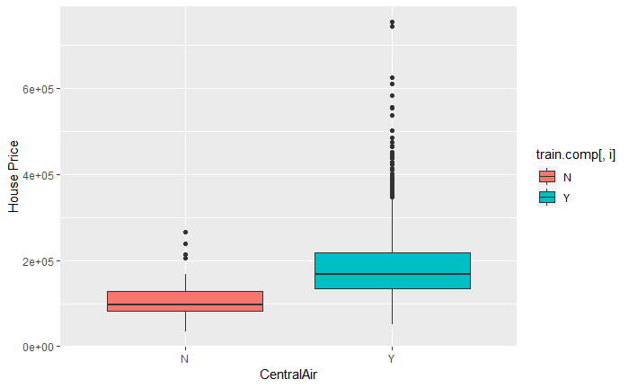

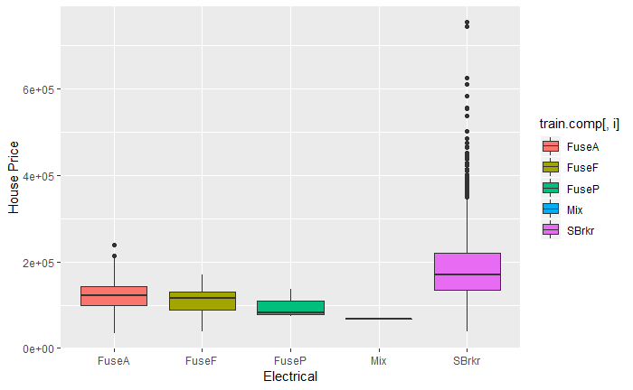

```r
#plot the boxplot for possible predictor
vector.equipment1<-c(41,42)
for (i in vector.equipment1){
  p.equipment<-ggplot(data=train.comp, aes(x=train.comp[,i],y=SalePrice,fill=train.comp[,i]))+
      geom_boxplot()+
      labs(y="House Price",x=colnames(train.comp)[i])
  print (p.equipment)
}
```

**Conclusion: We will keep 42.CentralAir,as 41.Electrical is correlated with CentralAir?**

3.layout

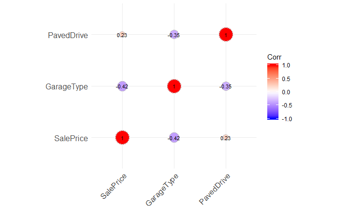

```r
#check the correlation for all the categorical variables between the layout
vector.layout<-which(colnames(train.comp)=="GarageType"|
                       #colnames(train.comp)=="Fireplaces"|
                       #colnames(train.comp)=="GarageCars"|
                       colnames(train.comp)=="PavedDrive")
df<-data.frame(train.comp[,c(80,vector.layout)])
df1 <-lapply(df,as.integer)#transform the categorical data into numeric
df1<-as.data.frame(df1)
corr.layout <- round(cor(df1), 2)
library(ggcorrplot)
ggcorrplot(corr.layout,method = "circle",lab=TRUE,lab_size=3)
```

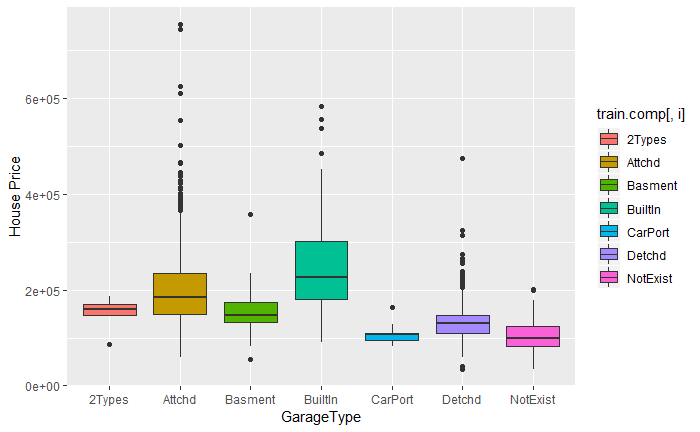

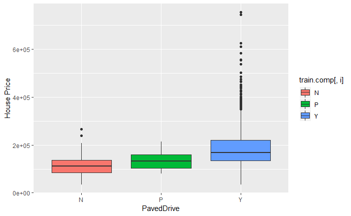

```r
#plot the boxplot for possible predictor for layout
vector.layout1<-c(58,65)
for (i in vector.layout1){
  p.layout<-ggplot(data=train.comp, aes(x=train.comp[,i],y=SalePrice,fill=train.comp[,i]))+
      geom_boxplot()+
      labs(y="House Price",x=colnames(train.comp)[i])
  print (p.layout)
}
```

4.location

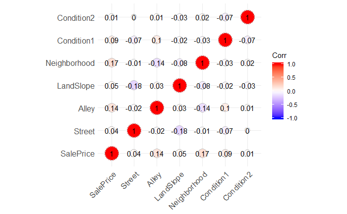

```r
#check the correlation for all the categorical variables between the location
vector.location<-which(colnames(train.comp)=="Street"|
                        colnames(train.comp)=="Alley"|
                        colnames(train.comp)=="LandSlope"|
                        colnames(train.comp)=="Neighborhood"|
                        colnames(train.comp)=="Condition1"|
                       colnames(train.comp)=="Condition2")
df2<-data.frame(train.comp[,c(80,vector.location)])
df3 <-lapply(df2,as.integer)#transform the categorical data into numeric
df3<-as.data.frame(df3)
corr.location <- round(cor(df3), 2)
library(ggcorrplot)
ggcorrplot(corr.location,method = "circle",lab=TRUE,lab_size = 4)
```

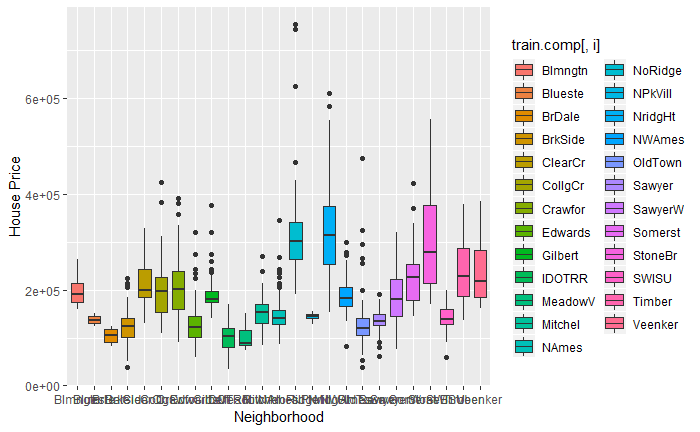

```r
#plot the boxplot for possible predictor for location
vector.location1<-c(12)
for (i in vector.location1){
  p.layout<-ggplot(data=train.comp, aes(x=train.comp[,i],y=SalePrice,fill=train.comp[,i]))+
      geom_boxplot()+
      labs(y="House Price",x=colnames(train.comp)[i])
  print (p.layout)
}
```

**Conclusion:12.Neighborhood looks important**

5.material

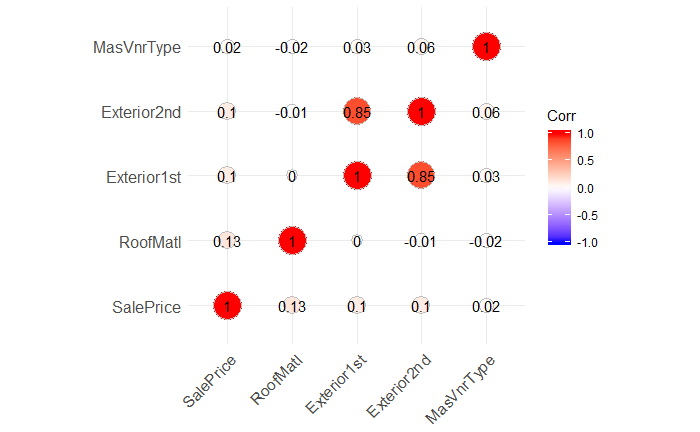

```r
#check the correlation for all the categorical variables between the material
vector.material<-which(colnames(train.comp)=="RoofMatl"|
                        colnames(train.comp)=="Exterior1st"|
                        colnames(train.comp)=="Exterior2nd"|
                        colnames(train.comp)=="MasVnrType")
df4<-data.frame(train.comp[,c(80,vector.material)])
#df4
df5 <-lapply(df4,as.integer)#transform the categorical data into numeric
df5<-as.data.frame(df5)
corr.material <- round(cor(df5), 2)
library(ggcorrplot)
ggcorrplot(corr.material,method = "circle",lab=TRUE,lab_size = 4)
```

**Here, we choose nothing as the correlation coefficient is small, by the way, Exterior1st and Exterior2nd(cor=0.85)**

6.quality

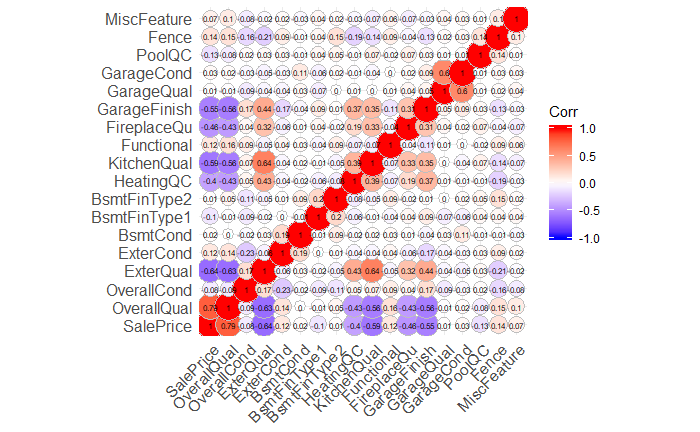

```r
#check the correlation for all the categorical variables between the quality
vector.quality<-which(colnames(train.comp)=="OverallQual"|
                        colnames(train.comp)=="OverallCond"|
                        colnames(train.comp)=="ExterQual"|
                        colnames(train.comp)=="ExterCond"|
                        colnames(train.comp)=="BsmtCond"|
                        colnames(train.comp)=="BsmtFinType1"|
                        colnames(train.comp)=="BsmtFinType2"|
                        colnames(train.comp)=="HeatingQC"|
                        colnames(train.comp)=="KitchenQual"|
                        colnames(train.comp)=="Functional"|
                        colnames(train.comp)=="FireplaceQu"|
                        colnames(train.comp)=="GarageFinish"|
                        colnames(train.comp)=="GarageQual"|
                        colnames(train.comp)=="GarageCond"|
                        colnames(train.comp)=="PoolQC"|
                        colnames(train.comp)=="Fence"|
                        colnames(train.comp)=="MiscFeature")
df.quality<-data.frame(train.comp[,c(80,vector.quality)])
df.quality1 <-lapply(df.quality,as.integer)#transform the categorical data into numeric
df.quality1<-as.data.frame(df.quality1)
corr.quality <- round(cor(df.quality1), 2)
library(ggcorrplot)
ggcorrplot(corr.quality,method = "circle",lab=TRUE,lab_size=2)
```

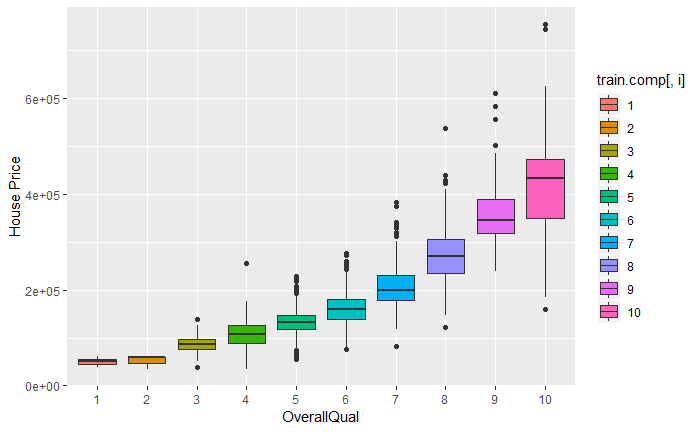

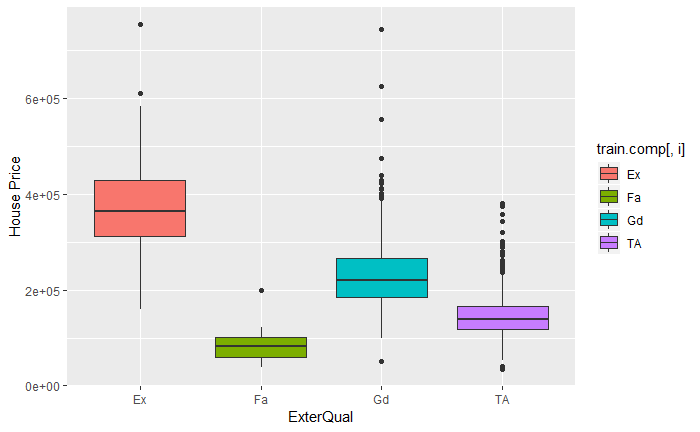

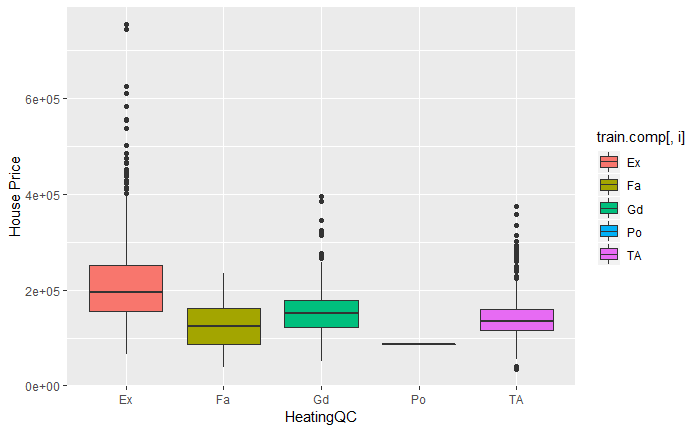

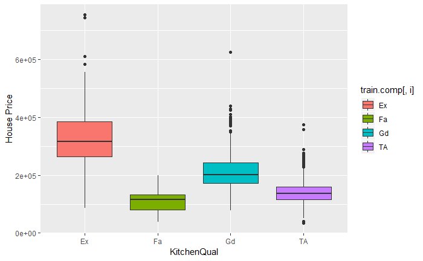

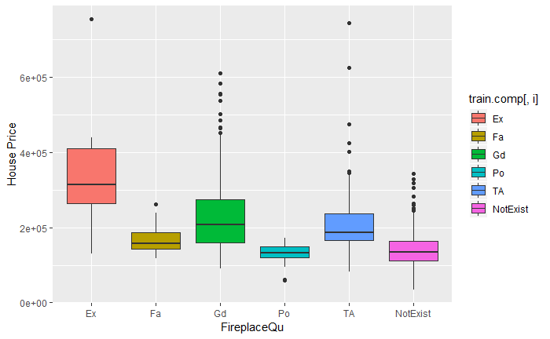

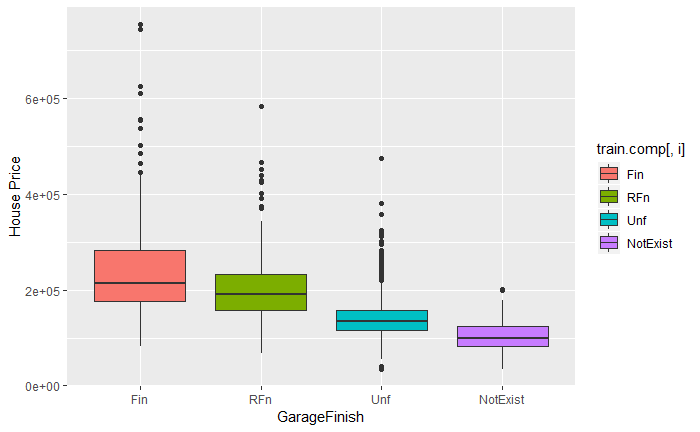

```r
#plot the boxplot for possible predictor for quality
vector.quality1<-c(17,27,40,53,57,60)
for (i in vector.quality1){
  p.layout<-ggplot(data=train.comp, aes(x=train.comp[,i],y=SalePrice,fill=train.comp[,i]))+
      geom_boxplot()+
      labs(y="House Price",x=colnames(train.comp)[i])
  print (p.layout)
}
```

**Conclusion: 17.OverallQual is a very important predictor. For the other 27.ExterQual,40.HeatingQC,53.KitchenQual,57.FireplaceQu,60.GarageFinish, they are important, but highly correlated with others, TBD**

7.sale

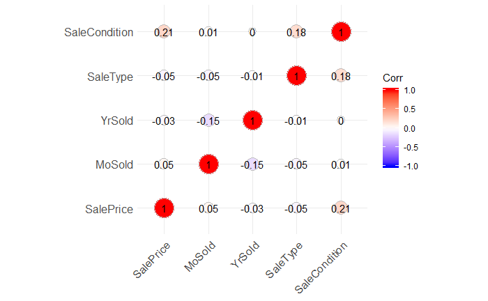

```r
#check the correlation for all the categorical variables between the sale
vector.sale<-which(colnames(train.comp)=="MoSold"|
                        colnames(train.comp)=="YrSold"|
                        colnames(train.comp)=="SaleType"|
                        colnames(train.comp)=="SaleCondition")
df.sale<-data.frame(train.comp[,c(80,vector.sale)])
df.sale1 <-lapply(df.sale,as.integer)#transform the categorical data into numeric
df.sale1<-as.data.frame(df.sale1)
corr.sale <- round(cor(df.sale1), 2)
library(ggcorrplot)
ggcorrplot(corr.sale,method = "circle",lab=TRUE)
```

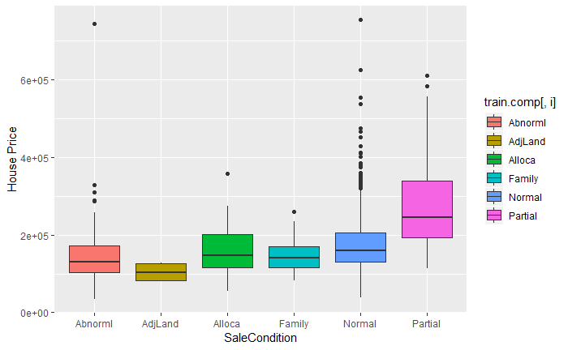

```r
#plot the boxplot for possible predictor for sale
vector.sale1<-c(79)
for (i in vector.sale1){
  p.layout<-ggplot(data=train.comp, aes(x=train.comp[,i],y=SalePrice,fill=train.comp[,i]))+
      geom_boxplot()+
      labs(y="House Price",x=colnames(train.comp)[i])
  print (p.layout)
}
```

**Conclusion:79.SaleCondition is important**

# 2. Build the model

## 2.1.Model:Linear Regression

Here we have two selections of variables, one is with the most important 30 predictors, the other is with 17 predictors.

### 2.1.1.Building the Model

Model1:With 30 predictors

```r
train.comp.p1<-train.comp[,c(4,5,8,12,16,17,19,21,26,27,29,30,32,38,40,41,42,46,50,53,54,56,57,58,60,61,65,66,67,79,80)]
#summary(train.comp.partial)
test.comp.p1<-test.comp[,c(1,4,5,8,12,16,17,19,21,26,27,29,30,32,38,40,41,42,46,50,53,54,56,57,58,60,61,65,66,67,79,80)]
#with all 30 important predictors with log tranformation of saleprice
fit.lm1<-lm(log(SalePrice)~.,data=train.comp.p1)
fit.lm1.step<-step(fit.lm1,direction = c("both"),trace=0)
summary(fit.lm1.step)
```

```
Call:
lm(formula = log(SalePrice) ~ LotArea + LotShape + Neighborhood +
    HouseStyle + OverallQual + YearBuilt + BsmtQual + BsmtExposure +
    HeatingQC + CentralAir + GrLivArea + HalfBath + KitchenQual +
    TotRmsAbvGrd + Fireplaces + GarageType + GarageFinish + GarageCars +
    PavedDrive + WoodDeckSF + OpenPorchSF + SaleCondition, data = train.comp.p1)

Residuals:
     Min       1Q   Median       3Q      Max
-1.43162 -0.06982  0.00561  0.07416  0.44470

Coefficients: (1 not defined because of singularities)
                       Estimate Std. Error t value Pr(>|t|)
(Intercept)           9.678e+00  6.814e-01  14.203  < 2e-16 ***
LotArea               1.719e-06  4.579e-07   3.753 0.000182 ***
LotShapeIR2           4.574e-02  2.365e-02   1.934 0.053293 .
LotShapeIR3          -1.218e-01  4.743e-02  -2.568 0.010334 *
LotShapeReg          -2.908e-03  8.747e-03  -0.332 0.739587
NeighborhoodBlueste  -3.346e-02  1.055e-01  -0.317 0.751170
NeighborhoodBrDale   -7.379e-02  5.398e-02  -1.367 0.171833
NeighborhoodBrkSide   8.239e-02  4.526e-02   1.820 0.068929 .
NeighborhoodClearCr   1.355e-01  4.694e-02   2.887 0.003950 **
NeighborhoodCollgCr   1.024e-01  3.738e-02   2.738 0.006252 **
NeighborhoodCrawfor   2.418e-01  4.415e-02   5.476 5.17e-08 ***
NeighborhoodEdwards   4.940e-03  4.121e-02   0.120 0.904585
NeighborhoodGilbert   9.226e-02  3.983e-02   2.316 0.020699 *
NeighborhoodIDOTRR   -5.459e-02  4.795e-02  -1.138 0.255151
NeighborhoodMeadowV  -1.644e-01  5.280e-02  -3.113 0.001891 **
NeighborhoodMitchel   6.947e-02  4.235e-02   1.640 0.101164
NeighborhoodNAmes     7.556e-02  3.982e-02   1.898 0.057925 .
NeighborhoodNoRidge   2.240e-01  4.366e-02   5.131 3.30e-07 ***
NeighborhoodNPkVill   5.819e-02  6.050e-02   0.962 0.336305
NeighborhoodNridgHt   1.898e-01  4.050e-02   4.686 3.07e-06 ***
NeighborhoodNWAmes    1.001e-01  4.099e-02   2.441 0.014775 *
NeighborhoodOldTown  -3.821e-04  4.390e-02  -0.009 0.993057
NeighborhoodSawyer    6.056e-02  4.207e-02   1.440 0.150169
NeighborhoodSawyerW   9.151e-02  4.068e-02   2.249 0.024651 *
NeighborhoodSomerst   1.515e-01  3.924e-02   3.861 0.000118 ***
NeighborhoodStoneBr   2.212e-01  4.621e-02   4.788 1.87e-06 ***
NeighborhoodSWISU     7.995e-02  5.098e-02   1.568 0.117040
```

[output cut: 49 more lines]

```
PavedDriveP           2.691e-02  3.089e-02   0.871 0.383828
PavedDriveY           4.700e-02  1.860e-02   2.527 0.011607 *
WoodDeckSF            1.185e-04  3.256e-05   3.641 0.000282 ***
OpenPorchSF           1.140e-04  6.229e-05   1.830 0.067435 .
SaleConditionAdjLand  1.468e-01  7.377e-02   1.990 0.046822 *
SaleConditionAlloca   3.164e-02  4.505e-02   0.702 0.482555
SaleConditionFamily   1.724e-02  3.489e-02   0.494 0.621199
SaleConditionNormal   9.529e-02  1.486e-02   6.415 1.94e-10 ***
SaleConditionPartial  1.150e-01  2.101e-02   5.473 5.27e-08 ***
---
Signif. codes:  0 *** 0.001 ** 0.01 * 0.05 . 0.1   1

Residual standard error: 0.1381 on 1376 degrees of freedom
Multiple R-squared:  0.8873,    Adjusted R-squared:  0.8805
F-statistic: 130.5 on 83 and 1376 DF,  p-value: < 2.2e-16
```

Model2: With 17 predictors

```r
train.comp.p2<-train.comp[,c(5,8,16,17,19,21,26,30,38,41,46,56,58,61,66,67,79,80)]
#summary(train.comp.partial)
test.comp.p2<-test.comp[,c(1,5,8,16,17,19,21,26,30,38,41,46,56,58,61,66,67,79,80)]
#with all 17 most important predictors with log tranformation of saleprice
fit.lm2<-lm(log(SalePrice)~.,data=train.comp.p2)
fit.lm2.step<-step(fit.lm2,direction = c("both"),trace=0)
summary(fit.lm2.step)
```

```
Call:
lm(formula = log(SalePrice) ~ LotArea + LotShape + HouseStyle +
    OverallQual + YearBuilt + BsmtQual + CentralAir + GrLivArea +
    Fireplaces + GarageType + GarageCars + WoodDeckSF + SaleCondition,
    data = train.comp.p2)

Residuals:
     Min       1Q   Median       3Q      Max
-1.65150 -0.07584  0.00722  0.08348  0.56604

Coefficients:
                       Estimate Std. Error t value Pr(>|t|)
(Intercept)           8.009e+00  5.485e-01  14.602  < 2e-16 ***
LotArea               2.585e-06  4.692e-07   5.511 4.24e-08 ***
LotShapeIR2           3.940e-02  2.599e-02   1.516 0.129720
LotShapeIR3          -2.224e-01  5.197e-02  -4.280 2.00e-05 ***
LotShapeReg          -2.660e-02  9.221e-03  -2.885 0.003977 **
HouseStyle1.5Unf      2.271e-02  4.430e-02   0.513 0.608181
HouseStyle1Story      6.557e-02  1.624e-02   4.037 5.71e-05 ***
HouseStyle2.5Fin     -4.092e-02  5.867e-02  -0.697 0.485622
HouseStyle2.5Unf     -7.628e-03  5.019e-02  -0.152 0.879220
HouseStyle2Story     -9.821e-03  1.625e-02  -0.604 0.545807
HouseStyleSFoyer      5.231e-02  3.097e-02   1.689 0.091388 .
HouseStyleSLvl        6.056e-02  2.494e-02   2.429 0.015284 *
OverallQual2         -7.213e-02  1.433e-01  -0.503 0.614839
OverallQual3          2.398e-01  1.165e-01   2.059 0.039677 *
OverallQual4          3.537e-01  1.133e-01   3.120 0.001842 **
OverallQual5          4.517e-01  1.136e-01   3.975 7.39e-05 ***
OverallQual6          5.037e-01  1.141e-01   4.413 1.10e-05 ***
OverallQual7          6.005e-01  1.148e-01   5.232 1.93e-07 ***
OverallQual8          7.227e-01  1.156e-01   6.254 5.27e-10 ***
OverallQual9          8.507e-01  1.186e-01   7.173 1.18e-12 ***
OverallQual10         7.549e-01  1.237e-01   6.105 1.33e-09 ***
YearBuilt             1.346e-03  2.717e-04   4.953 8.19e-07 ***
BsmtQualFa           -1.351e-01  3.744e-02  -3.608 0.000319 ***
BsmtQualGd           -6.634e-02  2.040e-02  -3.252 0.001172 **
BsmtQualTA           -1.031e-01  2.416e-02  -4.267 2.11e-05 ***
BsmtQualNotExist     -2.331e-01  3.560e-02  -6.547 8.16e-11 ***
CentralAirY           1.327e-01  1.995e-02   6.649 4.19e-11 ***
GrLivArea             2.826e-04  1.401e-05  20.173  < 2e-16 ***
Fireplaces            4.253e-02  7.737e-03   5.497 4.57e-08 ***
GarageTypeAttchd      8.308e-02  6.582e-02   1.262 0.207086
GarageTypeBasment     1.578e-02  7.532e-02   0.210 0.834069
GarageTypeBuiltIn     5.684e-02  6.823e-02   0.833 0.404927
GarageTypeCarPort    -6.509e-02  8.375e-02  -0.777 0.437158
GarageTypeDetchd      4.847e-02  6.572e-02   0.738 0.460900
GarageTypeNotExist    2.653e-02  7.163e-02   0.370 0.711203
GarageCars            6.877e-02  9.491e-03   7.246 7.02e-13 ***
WoodDeckSF            1.058e-04  3.528e-05   2.998 0.002763 **
SaleConditionAdjLand  1.289e-01  8.034e-02   1.604 0.108909
SaleConditionAlloca   2.054e-02  4.878e-02   0.421 0.673728
SaleConditionFamily   1.940e-02  3.828e-02   0.507 0.612487
SaleConditionNormal   9.822e-02  1.633e-02   6.014 2.31e-09 ***
SaleConditionPartial  1.373e-01  2.262e-02   6.070 1.63e-09 ***
---
Signif. codes:  0 *** 0.001 ** 0.01 * 0.05 . 0.1   1

Residual standard error: 0.1543 on 1418 degrees of freedom
Multiple R-squared:  0.855, Adjusted R-squared:  0.8508
F-statistic:   204 on 41 and 1418 DF,  p-value: < 2.2e-16
```

**From the above, we can find that second model is better, as it has fewer predictors with only a fewer decrease of R-squared. Therefore, I will choose this model.**

### 2.1.2.Cross Validation to calculate the MSE

```r
set.seed(1)
k = 10 # 5-fold cross-validation
folds = sample(1:k, nrow(train.comp.p2), replace = T)
test_error_lm = NULL
for (i in 1:k) {
fit.lm.cv<-lm(log(SalePrice)~.,data=train.comp.p2[folds!=i,])
fit.lm.step.cv<-step(fit.lm.cv,direction = c("both"),trace=0)
pred_lm.cv<-exp(predict(fit.lm.step.cv,train.comp.p2[folds==i,],type="response"))
test_error_lm[i] = mean((train.comp.p2$SalePrice[folds == i] - pred_lm.cv)^2)
}
mean(test_error_lm)
```

```
[1] 2406676153
```

### 2.1.3.Prediction

```r
test_SalePrice<-exp(predict(fit.lm2.step,test.comp.p2))
summary(test_SalePrice)
```

```
   Min. 1st Qu.  Median    Mean 3rd Qu.    Max.
  44237  126901  158662  177676  206681  960675
```

```r
submit <- data.frame(Id = test.comp.p2$Id, SalePrice = round(test_SalePrice,0))
# Create submission file
write.csv(submit, "E:/Loyola/Fall 2018/STAT 388 001 Predictive Analytics/Project/prediction/submissionfile.fit.lm2.csv", row.names = FALSE)
```

**The Adjusted R-squared is 0.851 ,The MSE is 2.41e+09, and the score in kaggle is 0.15111.**

## 2.2.Model:GAM model

### 2.2.1.Building the Model

**Using 17 important predictors to build the GAM model**

```r
library(mgcv)
fit.gam<- gam(data = train.comp.p2,log(SalePrice) ~ s(LotArea) + LotShape+HouseStyle+OverallQual+s(YearBuilt)+RoofStyle+s(MasVnrArea)+BsmtQual+s(TotalBsmtSF)+CentralAir+s(GrLivArea)+Fireplaces+GarageType+GarageCars+s(WoodDeckSF)+s(OpenPorchSF)+SaleCondition, method = "REML", select = TRUE)
summary(fit.gam)
```

```
Family: gaussian
Link function: identity

Formula:
log(SalePrice) ~ s(LotArea) + LotShape + HouseStyle + OverallQual +
    s(YearBuilt) + RoofStyle + s(MasVnrArea) + BsmtQual + s(TotalBsmtSF) +
    CentralAir + s(GrLivArea) + Fireplaces + GarageType + GarageCars +
    s(WoodDeckSF) + s(OpenPorchSF) + SaleCondition

Parametric coefficients:
                      Estimate Std. Error t value Pr(>|t|)
(Intercept)          11.266365   0.132209  85.216  < 2e-16 ***
LotShapeIR2           0.027302   0.023789   1.148 0.251289
LotShapeIR3          -0.034201   0.049636  -0.689 0.490910
LotShapeReg          -0.020343   0.008480  -2.399 0.016575 *
HouseStyle1.5Unf      0.028052   0.041233   0.680 0.496406
HouseStyle1Story      0.046506   0.018296   2.542 0.011136 *
HouseStyle2.5Fin     -0.062740   0.055863  -1.123 0.261579
HouseStyle2.5Unf      0.008518   0.046056   0.185 0.853294
HouseStyle2Story      0.023128   0.016055   1.441 0.149927
HouseStyleSFoyer      0.089077   0.031053   2.869 0.004185 **
HouseStyleSLvl        0.090984   0.024110   3.774 0.000168 ***
OverallQual2          0.039976   0.129020   0.310 0.756729
OverallQual3          0.187850   0.106512   1.764 0.078011 .
OverallQual4          0.304475   0.103487   2.942 0.003313 **
OverallQual5          0.386169   0.104060   3.711 0.000215 ***
OverallQual6          0.436279   0.104580   4.172 3.21e-05 ***
OverallQual7          0.515494   0.105262   4.897 1.09e-06 ***
OverallQual8          0.624497   0.105967   5.893 4.74e-09 ***
OverallQual9          0.739621   0.108883   6.793 1.62e-11 ***
OverallQual10         0.842798   0.114213   7.379 2.73e-13 ***
RoofStyleGable       -0.038198   0.041327  -0.924 0.355489
RoofStyleGambrel     -0.025798   0.058979  -0.437 0.661879
RoofStyleHip         -0.036192   0.041870  -0.864 0.387519
RoofStyleMansard     -0.018192   0.067791  -0.268 0.788469
RoofStyleShed        -0.014718   0.106633  -0.138 0.890244
BsmtQualFa           -0.102345   0.033819  -3.026 0.002522 **
BsmtQualGd           -0.053566   0.018645  -2.873 0.004129 **
BsmtQualTA           -0.087766   0.022765  -3.855 0.000121 ***
BsmtQualNotExist     -0.003382   0.052732  -0.064 0.948873
```

[output cut: 16 more lines]

```

Approximate significance of smooth terms:
                     edf Ref.df      F  p-value
s(LotArea)     5.1198609      9  7.059 7.02e-14 ***
s(YearBuilt)   3.7837265      9  4.452 1.68e-09 ***
s(MasVnrArea)  0.0008097      9  0.000 0.658163
s(TotalBsmtSF) 4.4748112      9  6.042 9.53e-13 ***
s(GrLivArea)   6.0931941      9 29.172  < 2e-16 ***
s(WoodDeckSF)  1.7107204      9  1.627 0.000104 ***
s(OpenPorchSF) 3.1239629      9  2.335 2.98e-05 ***
---
Signif. codes:  0 *** 0.001 ** 0.01 * 0.05 . 0.1   1

R-sq.(adj) =  0.882   Deviance explained = 88.8%
-REML = -690.33  Scale est. = 0.018793  n = 1460
```

### 2.2.2.Cross Validation to calculate the MSE

```r
set.seed(1)
k = 10 # 5-fold cross-validation
folds = sample(1:k, nrow(train.comp.p2), replace = T)
test_error_gam = NULL
for (i in 1:k) {
fit.gam.cv<- gam(data = train.comp.p2[folds!=i,],log(SalePrice) ~ s(LotArea) + LotShape+HouseStyle+OverallQual+s(YearBuilt)+RoofStyle+s(MasVnrArea)+BsmtQual+s(TotalBsmtSF)+CentralAir+s(GrLivArea)+Fireplaces+GarageType+GarageCars+s(WoodDeckSF)+s(OpenPorchSF)+SaleCondition, method = "REML", select = TRUE)
pred_gam.cv<-exp(predict(fit.gam.cv,train.comp.p2[folds==i,],type="response"))
test_error_gam[i] = mean((train.comp.p2$SalePrice[folds == i] - pred_gam.cv)^2)
}
mean(test_error_gam)
```

```
[1] 1229821339
```

### 2.2.3.Prediction

```r
test_SalePrice<-exp(predict(fit.gam,test.comp.p2))
summary(test_SalePrice)
```

```
   Min. 1st Qu.  Median    Mean 3rd Qu.    Max.
  45998  127418  157963  177902  207892  586572
```

```r
submit <- data.frame(Id = test.comp.p2$Id, SalePrice = round(test_SalePrice,0))
# Create submission file
write.csv(submit, "E:/Loyola/Fall 2018/STAT 388 001 Predictive Analytics/Project/prediction/submissionfile.fit.gam.csv", row.names = FALSE)
```

**The Adjusted R-squared is 0.882,The MSE is 1.23e+09, and the score in kaggle is 0.14583**

## 2.3.Model: Random forest with orginal dataset

### 2.3.1.Building the Model

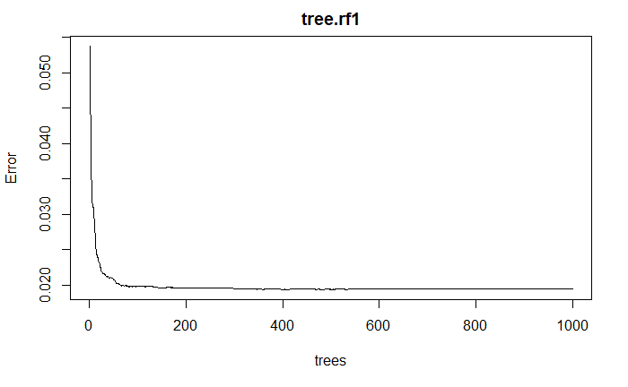

```r
#random forest with log of Saleprice
set.seed(1)
library(randomForest)
tree.rf1<-randomForest(log(SalePrice)~.,data=train.comp[,-1],mtry=26,ntree=1000,importance=TRUE)
plot(tree.rf1)
```

```r
importance(tree.rf1)
```

```
                  %IncMSE IncNodePurity
MSSubClass    32.89039783    4.57056780
MSZoning      11.70324875    0.96902853
LotFrontage   12.16944862    1.09601247
LotArea       24.32888524    2.63590451
Street        -2.50914529    0.01846633
Alley          1.50847825    0.12837234
LotShape       6.07062201    0.19686445
LandContour    3.91127106    0.22285758
LotConfig      0.43602424    0.18100659
LandSlope      2.20812740    0.10635107
Neighborhood  45.87224794   32.53610282
Condition1     1.77351986    0.23995545
Condition2    -0.24306809    0.02435770
BldgType       7.64397096    0.14666081
HouseStyle    13.20001848    0.45686241
OverallQual   36.74838132   54.21771978
OverallCond   18.55163061    1.69566137
YearBuilt     14.01617320    7.87716377
YearRemodAdd  15.30949737    1.60283251
RoofStyle      3.94444028    0.18896345
RoofMatl      -0.61132757    0.04671864
Exterior1st   13.68197067    1.41268959
Exterior2nd   13.06247836    1.58026804
MasVnrType     5.95192361    0.18621679
MasVnrArea    10.79233484    0.57871584
ExterQual     17.11096993   17.10599606
ExterCond      2.06943122    0.36259722
Foundation     7.84833343    0.30700996
BsmtQual       9.82250588    3.25522017
BsmtCond       9.68440373    0.36786862
BsmtExposure  10.15380553    0.53319391
BsmtFinType1  17.11012777    1.17473564
BsmtFinSF1    29.35515447    3.19558394
BsmtFinType2   1.31418424    0.20900419
BsmtFinSF2     0.05155392    0.09497983
BsmtUnfSF     11.39174920    0.86471673
TotalBsmtSF   33.12757811    8.05077182
Heating       -2.10733614    0.08324391
HeatingQC      6.02496529    0.44975263
```

[output cut: 24 more lines]

```
PavedDrive     4.58254699    0.22200814
WoodDeckSF     8.13316552    0.49805726
OpenPorchSF   10.00386682    0.80838993
EnclosedPorch  3.41957464    0.27870778
X3SsnPorch     1.48368924    0.02146149
ScreenPorch    5.94021972    0.11768958
PoolArea      -1.31934597    0.01991108
PoolQC        -0.56222540    0.01960936
Fence         -0.35039712    0.25227689
MiscFeature    0.26181447    0.03343132
MiscVal        2.32009441    0.04190700
MoSold         1.67783339    2.70106882
YrSold        -0.35586523    0.63427007
SaleType       2.25923658    0.14781059
SaleCondition  0.88932442    0.57300235
```

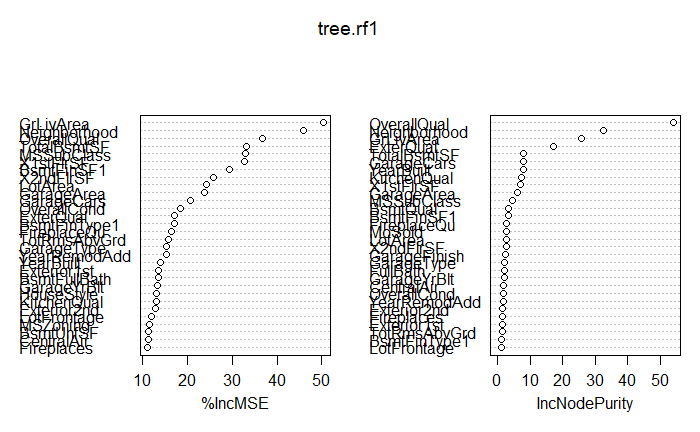

```r
varImpPlot(tree.rf1)
```

### 2.3.2.Cross Validation to calculate the MSE

```r
set.seed(1)
k = 10 # 5-fold cross-validation
folds = sample(1:k, nrow(train.comp), replace = T)
test_error_rf = NULL
for (i in 1:k) {
set.seed(123456789)
tree.rf.cv<-randomForest(log(SalePrice)~.,data=train.comp[,-1][folds!=i,],mtry=26,ntree=1000,importance=TRUE)
pred_rf.cv<-exp(predict(tree.rf.cv,train.comp[folds==i,],type="response"))
test_error_rf[i] = mean((train.comp$SalePrice[folds==i]-pred_rf.cv)^2)
}
mean(test_error_rf)
```

```
[1] 827577893
```

### 2.3.3.Prediction

```r
test_SalePrice<-exp(predict(tree.rf1,newdata=test.comp))
summary(test_SalePrice)
```

```
   Min. 1st Qu.  Median    Mean 3rd Qu.    Max.
  63439  131310  156562  175547  203685  465873
```

```r
# Create submission file
submit <- data.frame(Id = test.comp$Id, SalePrice = round(test_SalePrice,0))
write.csv(submit, "E:/Loyola/Fall 2018/STAT 388 001 Predictive Analytics/Project/prediction/submissionfile.fit.rf1.csv", row.names = FALSE)
```

**The MSE is 827577893, and the score in kaggle is 0.14974**

## 2.4.Model:Boosting

### 2.4.1.Building the Model

|  | var | rel.inf |
| --- | --- | --- |
| OverallQual | OverallQual | 28.969742048 |
| Neighborhood | Neighborhood | 16.169726681 |
| GrLivArea | GrLivArea | 15.622289259 |
| TotalBsmtSF | TotalBsmtSF | 4.052420885 |
| KitchenQual | KitchenQual | 2.615507797 |
| X1stFlrSF | X1stFlrSF | 2.410829832 |
| MSSubClass | MSSubClass | 1.959889823 |
| GarageCars | GarageCars | 1.955695572 |
| GarageArea | GarageArea | 1.888808284 |
| OverallCond | OverallCond | 1.888764338 |

[output cut: 68 more lines]

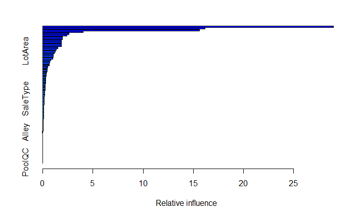

```r
library(gbm)
fit.boost<-gbm(log(SalePrice)~., data=train.comp[,-1], distribution="gaussian",n.trees=5000,interaction.depth=4,shrinkage=0.01)
summary(fit.boost)
```

### 2.4.2.Cross Validation to calculate the MSE

```r
set.seed(1)
k = 10 # 5-fold cross-validation
folds = sample(1:k, nrow(train.comp), replace = T)
test_error_boosting = NULL
for (i in 1:k) {
set.seed(123456789)
tree.boosting.cv<-gbm(log(SalePrice)~.,data=train.comp[,-1][folds!=i,],distribution="gaussian",n.trees=5000,interaction.depth=4,shrinkage=0.01)
pred_boosting.cv<-exp(predict(tree.boosting.cv,train.comp[,-1][folds==i,],n.trees=5000,type="response"))
test_error_boosting[i] = mean((train.comp[,-1]$SalePrice[folds==i]-pred_boosting.cv)^2)
}
```

### 2.4.3.Prediction

```r
test_SalePrice<-exp(predict(fit.boost,newdata=test.comp,n.trees=5000))
summary(test_SalePrice)
```

```
   Min. 1st Qu.  Median    Mean 3rd Qu.    Max.
  41379  129551  158696  180306  210384  552178
```

```r
# Create submission file
submit <- data.frame(Id = test.comp$Id, SalePrice = round(test_SalePrice,0))
write.csv(submit, "E:/Loyola/Fall 2018/STAT 388 001 Predictive Analytics/Project/prediction/submissionfile.fit.boosting.csv", row.names = FALSE)
```

**The MSE is 2988325798, and the score in kaggle is 0.12825**

# 3.Conclusion

## 3.1.Recap

In this project, we first cleaned the data, including transfering the type of variables, checking the missing values as well as imputing those truly missing values. Here we found those variables (MSZoning,LotFrontage,Utilities,Exterior1st, Exterior2nd,MasVnrType, BsmtFinSF1,BsmtFinSF2,BsmtUnfSF,Electrical,BsmtFullBath,BsmtHalfBath,Functional,GarageCars,KitchenQual,SaleType.) are missing. But for Utilities,only 1 obs is NoSeWa, while 2918 are AllPub, so we dropped this variable in the following analysis. For the missing value, we imputed them with the median value(those variables with a few NA) and the prediction from linear model(numerical data).

Meanwhile,we analyzed all the variables before buiding the linear regression and GAM.Firstly, we transformed the response variables with log function, with the purpose to have a normal distribution.Secondly,for the continous variables, we made the correlation matrix plot to find out the most important variables to predict the SalePrice. In this step, we choosed the variables with correlation coefficient higher than 0.2. Among those multicorrelated variables, we choosed the one with highest correlated with SalePrice. Thus, we have the following variables:LotArea, YearBuilt, MasVnrArea,TotalBsmtSf, GrLivArea,Fireplaces, GarageCars, WoodDeckSF and OpenPorchSF. Thirdly, we grouped the categorical variables (such as design,location, layout,quality,equipment,sale, time) and made the boxplot to find out the possible relationship with response variables. In this way, we have the following variables that might be important:LotShape,HouseStyle,OverallQual, RoofStyle, BsmtQual, CentralAir,GarageType and SaleCondition.

Besides,we applied the random forest and boosting with all the 78 variables. For each model, we calculated the MSE with 10-fold cross validation and predicted the SalePrice of test dataset.

```r
test_error = data.frame(
        Model = c("Linear Regression","GAM","Random Forest", "Boosting"),
        Test_Error = c(mean(test_error_lm), mean(test_error_gam),mean(test_error_rf), mean(test_error_boosting)),
        kaggle_score=c(0.15111,0.14583,0.14974,0.12825))
test_error[order(test_error$kaggle_score),]
```

|  | Model | Test_Error | kaggle_score |
| --- | --- | --- | --- |
| 4 | Boosting | 2988325798 | 0.12825 |
| 2 | GAM | 1229821339 | 0.14583 |
| 3 | Random Forest | 827577893 | 0.14974 |
| 1 | Linear Regression | 2406676153 | 0.15111 |

**According to the above result, the lowest MSE is the Random forest, but this is the mean error based on the train dataset.When it was tested in the test dataset, the best model is Boosting. In summary,we can find the best model here is the Boosting.**

```r
#summary(house$SalePrice)
pre.sum<- data.frame(
         Model = c("train dataset","Linear Regression","GAM","Random Forest", "Boosting"),              min=c(34900,44237,45998,63439,41197),
         Q1= c(129975,126901,127418,131310,128435),
         median=c(163000,158662,157963,156562,158509),
         mean=c(180921,177676,177902,175547,179469),
         Q3=c(214000,206681,207892,203685,209840),
         max=c(755000,960675,586572,465873,538248))
pre.sum
```

[output not shown]

```r
#summary(train.comp$SalePrice)
```

**From the prediction result, we can find the model predict very well for the Saleprice between Q1 and Q3, but did not preform well for the lowest and the most expensive houses.**

## 3.2.Possible improvement:

Because of limited time, I didn’t try the following ideas that I think they might improve the model.

### 3.2.1.Combine variables

Here there are several variables are highly correlated, we can create variables that sum up the values. For example. “FlrSF=X1stFlrSF+X2ndFlrSF”.

### 3.2.2.Data transformation

Data transformation predominantly deals with normalizing also known as scaling data, handling skewness and aggregation of attributes.This is because if we want to use the Linear Regression model, one of the important assumption is Homoscedasticity, which could be ensured by making sure that Y follows a Gaussian distribution.Therefore we need transform data to make it fit a Gaussian distribution. Here we can find some of the variables are seriouly skewed(the skewness of variable is larger than 1 or less than -1, which means it is serious skewed).

**Therefore, we should transform LotFrontage,LotArea,MasVnrArea,BsmtFinSF1,BsmtFinSF2, TotalBsmtSF, X1stFlrSF, LowQualFinSF,GrLivArea, BsmtHalfBath,KitchenAbvGr,WoodDeckSF,OpenPorchSF,EnclosedPorch,X3SsnPorch,ScreenPorch,PoolArea and MiscVal.For highly skewed numeric variables with lots of 0,we can transform them with log(x + 1).**

**Besides, here the range of the contious data are quite different, so it is better to scale the data before building the model.**

# 4.Reference

1).https://www.kaggle.com/notaapple/detailed-exploratory-data-analysis-using-r

2).https://www.kaggle.com/pmarcelino/comprehensive-data-exploration-with-python

3).https://www.kaggle.com/ozagordi/a-clear-example-of-overfitting

4).https://www.kaggle.com/jimthompson/ensemble-model-stacked-model-example

5).https://www.kaggle.com/erikbruin/house-prices-lasso-xgboost-and-a-detailed-eda